# 1 Import libraries and turnoff warnings

```python
import warnings
warnings.filterwarnings("ignore")

import pandas as pd
import seaborn as sns
import matplotlib.pyplot as plt
import pandas_profiling
sns.set(color_codes=True)
%matplotlib inline
```

# 2 Import dataset and quality of data

## 2.1 Quality of data

```python
# read data from csv file
data = pd.read_csv('CardioGoodFitness.csv')
```

```python
# get columns
data.columns
```

```
Index(['Product', 'Age', 'Gender', 'Education', 'MaritalStatus', 'Usage',
       'Fitness', 'Income', 'Miles'],
      dtype='object')
```

```python
# get size of dataset
data.shape
```

```
(180, 9)
```

```python
# check dataset information
data.info()
```

```
<class 'pandas.core.frame.DataFrame'>
RangeIndex: 180 entries, 0 to 179
Data columns (total 9 columns):
 #   Column         Non-Null Count  Dtype
---  ------         --------------  -----
 0   Product        180 non-null    object
 1   Age            180 non-null    int64
 2   Gender         180 non-null    object
 3   Education      180 non-null    int64
 4   MaritalStatus  180 non-null    object
 5   Usage          180 non-null    int64
 6   Fitness        180 non-null    int64
 7   Income         180 non-null    int64
 8   Miles          180 non-null    int64
dtypes: int64(6), object(3)
memory usage: 12.8+ KB
```

```python
# check dataset missing values
total = data.isnull().sum()   # total number of null values
print(total)
```

```
Product          0
Age              0
Gender           0
Education        0
MaritalStatus    0
Usage            0
Fitness          0
Income           0
Miles            0
dtype: int64
```

From this first analysis about the quality of the data we conclude that data set has 9 series, 180 rows of data and no missing values.

There are 4 categorical [Product, Gender, Fitness, Marital Status] and 5 numerical [Age, Education, Income, Usage, Miles] data series.

## 2.2 Characteristics of the data

```python
# check first rows of data
data.head()
```

|  | Product | Age | Gender | Education | MaritalStatus | Usage | Fitness | Income | Miles |
| --- | --- | --- | --- | --- | --- | --- | --- | --- | --- |
| 0 | TM195 | 18 | Male | 14 | Single | 3 | 4 | 29562 | 112 |
| 1 | TM195 | 19 | Male | 15 | Single | 2 | 3 | 31836 | 75 |
| 2 | TM195 | 19 | Female | 14 | Partnered | 4 | 3 | 30699 | 66 |
| 3 | TM195 | 19 | Male | 12 | Single | 3 | 3 | 32973 | 85 |
| 4 | TM195 | 20 | Male | 13 | Partnered | 4 | 2 | 35247 | 47 |

```python
# get statistcs about dataseries
data.describe()
```

|  | Age | Education | Usage | Fitness | Income | Miles |
| --- | --- | --- | --- | --- | --- | --- |
| count | 180.000000 | 180.000000 | 180.000000 | 180.000000 | 180.000000 | 180.000000 |
| mean | 28.788889 | 15.572222 | 3.455556 | 3.311111 | 53719.577778 | 103.194444 |
| std | 6.943498 | 1.617055 | 1.084797 | 0.958869 | 16506.684226 | 51.863605 |
| min | 18.000000 | 12.000000 | 2.000000 | 1.000000 | 29562.000000 | 21.000000 |
| 25% | 24.000000 | 14.000000 | 3.000000 | 3.000000 | 44058.750000 | 66.000000 |
| 50% | 26.000000 | 16.000000 | 3.000000 | 3.000000 | 50596.500000 | 94.000000 |
| 75% | 33.000000 | 16.000000 | 4.000000 | 4.000000 | 58668.000000 | 114.750000 |
| max | 50.000000 | 21.000000 | 7.000000 | 5.000000 | 104581.000000 | 360.000000 |

We get basic statistics of the data series using the describe() function. The difference between the mean and the median is small for all series, but we need to carry out a more in deep analysis to understand the distribution of the series and the relationships between them

## 2.3 Analysis by Product

In this section we are going to filter the data for each product to extract different metrics about customers

```python
data.Product.unique()
```

```
array(['TM195', 'TM498', 'TM798'], dtype=object)
```

There are 3 different products. Now, we are going to create subsets for each product

```python
# Creating subsets of data for each product
data_TM195 = data[data['Product']=='TM195']
data_TM498 = data[data['Product']=='TM498']
data_TM798 = data[data['Product']=='TM798']
```

### 2.3.1 TM195

```python
# Count by gender
data_TM195['Gender'].value_counts()
```

```
Female    40
Male      40
Name: Gender, dtype: int64
```

```python
# Count by Marital Status
data_TM195['MaritalStatus'].value_counts()
```

```
Partnered    48
Single       32
Name: MaritalStatus, dtype: int64
```

```python
# Get basic stats for dataset
data_TM195.describe()
```

|  | Age | Education | Usage | Fitness | Income | Miles |
| --- | --- | --- | --- | --- | --- | --- |
| count | 80.000000 | 80.000000 | 80.000000 | 80.00000 | 80.00000 | 80.000000 |
| mean | 28.550000 | 15.037500 | 3.087500 | 2.96250 | 46418.02500 | 82.787500 |
| std | 7.221452 | 1.216383 | 0.782624 | 0.66454 | 9075.78319 | 28.874102 |
| min | 18.000000 | 12.000000 | 2.000000 | 1.00000 | 29562.00000 | 38.000000 |
| 25% | 23.000000 | 14.000000 | 3.000000 | 3.00000 | 38658.00000 | 66.000000 |
| 50% | 26.000000 | 16.000000 | 3.000000 | 3.00000 | 46617.00000 | 85.000000 |
| 75% | 33.000000 | 16.000000 | 4.000000 | 3.00000 | 53439.00000 | 94.000000 |
| max | 50.000000 | 18.000000 | 5.000000 | 5.00000 | 68220.00000 | 188.000000 |

```python
# Average values by Gender
data_TM195.groupby(by='Gender').mean()
```

| Gender | Age | Education | Usage | Fitness | Income | Miles |
| --- | --- | --- | --- | --- | --- | --- |
| Female | 28.45 | 15.100 | 2.900 | 2.875 | 46020.075 | 76.200 |
| Male | 28.65 | 14.975 | 3.275 | 3.050 | 46815.975 | 89.375 |

```python
# Average values by Marital Status
data_TM195.groupby(by='MaritalStatus').mean()
```

| MaritalStatus | Age | Education | Usage | Fitness | Income | Miles |
| --- | --- | --- | --- | --- | --- | --- |
| Partnered | 29.666667 | 15.12500 | 3.041667 | 2.854167 | 47848.7500 | 77.229167 |
| Single | 26.875000 | 14.90625 | 3.156250 | 3.125000 | 44271.9375 | 91.125000 |

### 2.3.2 TM498

```python
# Count by gender
data_TM498['Gender'].value_counts()
```

```
Male      31
Female    29
Name: Gender, dtype: int64
```

```python
# Count by Marital Status
data_TM498['MaritalStatus'].value_counts()
```

```
Partnered    36
Single       24
Name: MaritalStatus, dtype: int64
```

```python
# Get basic stats for dataset
data_TM498.describe()
```

|  | Age | Education | Usage | Fitness | Income | Miles |
| --- | --- | --- | --- | --- | --- | --- |
| count | 60.000000 | 60.000000 | 60.000000 | 60.00000 | 60.000000 | 60.000000 |
| mean | 28.900000 | 15.116667 | 3.066667 | 2.90000 | 48973.650000 | 87.933333 |
| std | 6.645248 | 1.222552 | 0.799717 | 0.62977 | 8653.989388 | 33.263135 |
| min | 19.000000 | 12.000000 | 2.000000 | 1.00000 | 31836.000000 | 21.000000 |
| 25% | 24.000000 | 14.000000 | 3.000000 | 3.00000 | 44911.500000 | 64.000000 |
| 50% | 26.000000 | 16.000000 | 3.000000 | 3.00000 | 49459.500000 | 85.000000 |
| 75% | 33.250000 | 16.000000 | 3.250000 | 3.00000 | 53439.000000 | 106.000000 |
| max | 48.000000 | 18.000000 | 5.000000 | 4.00000 | 67083.000000 | 212.000000 |

```python
# Average by Gender
data_TM498.groupby(by='Gender').mean()
```

| Gender | Age | Education | Usage | Fitness | Income | Miles |
| --- | --- | --- | --- | --- | --- | --- |
| Female | 29.103448 | 15.206897 | 3.137931 | 2.862069 | 49336.448276 | 87.344828 |
| Male | 28.709677 | 15.032258 | 3.000000 | 2.935484 | 48634.258065 | 88.483871 |

```python
# Average values by Marital Status
data_TM498.groupby(by='MaritalStatus').mean()
```

| MaritalStatus | Age | Education | Usage | Fitness | Income | Miles |
| --- | --- | --- | --- | --- | --- | --- |
| Partnered | 30.222222 | 15.250000 | 3.055556 | 2.916667 | 49522.666667 | 90.055556 |
| Single | 26.916667 | 14.916667 | 3.083333 | 2.875000 | 48150.125000 | 84.750000 |

### 2.3.3 TM798

```python
# Count by gender
data_TM798['Gender'].value_counts()
```

```
Male      33
Female     7
Name: Gender, dtype: int64
```

```python
# Count by Marital Status
data_TM798['MaritalStatus'].value_counts()
```

```
Partnered    23
Single       17
Name: MaritalStatus, dtype: int64
```

```python
# Get basic stats for dataset
data_TM798.describe()
```

|  | Age | Education | Usage | Fitness | Income | Miles |
| --- | --- | --- | --- | --- | --- | --- |
| count | 40.000000 | 40.000000 | 40.000000 | 40.000000 | 40.00000 | 40.000000 |
| mean | 29.100000 | 17.325000 | 4.775000 | 4.625000 | 75441.57500 | 166.900000 |
| std | 6.971738 | 1.639066 | 0.946993 | 0.667467 | 18505.83672 | 60.066544 |
| min | 22.000000 | 14.000000 | 3.000000 | 3.000000 | 48556.00000 | 80.000000 |
| 25% | 24.750000 | 16.000000 | 4.000000 | 4.000000 | 58204.75000 | 120.000000 |
| 50% | 27.000000 | 18.000000 | 5.000000 | 5.000000 | 76568.50000 | 160.000000 |
| 75% | 30.250000 | 18.000000 | 5.000000 | 5.000000 | 90886.00000 | 200.000000 |
| max | 48.000000 | 21.000000 | 7.000000 | 5.000000 | 104581.00000 | 360.000000 |

```python
# Average by Gender
data_TM798.groupby(by='Gender').mean()
```

| Gender | Age | Education | Usage | Fitness | Income | Miles |
| --- | --- | --- | --- | --- | --- | --- |
| Female | 27.000000 | 17.857143 | 5.000000 | 4.571429 | 73633.857143 | 180.000000 |
| Male | 29.545455 | 17.212121 | 4.727273 | 4.636364 | 75825.030303 | 164.121212 |

```python
# Average values by Marital Status
data_TM798.groupby(by='MaritalStatus').mean()
```

| MaritalStatus | Age | Education | Usage | Fitness | Income | Miles |
| --- | --- | --- | --- | --- | --- | --- |
| Partnered | 29.826087 | 17.434783 | 4.913043 | 4.695652 | 82047.173913 | 183.043478 |
| Single | 28.117647 | 17.176471 | 4.588235 | 4.529412 | 66504.588235 | 145.058824 |

# 3 Distributions and relationships between variables

## 3.1 Univariate Analysis using Pandas profile

The pandas profile module allows to perform univariate data analysis

```python
# get pandas profile report
pandas_profiling.ProfileReport(data)
```

[interactive chart not shown]

## 3.2 Multivariate analysis - Relationships and correlations between variables

Plot pairwise relationships in the dataset using pairplot function

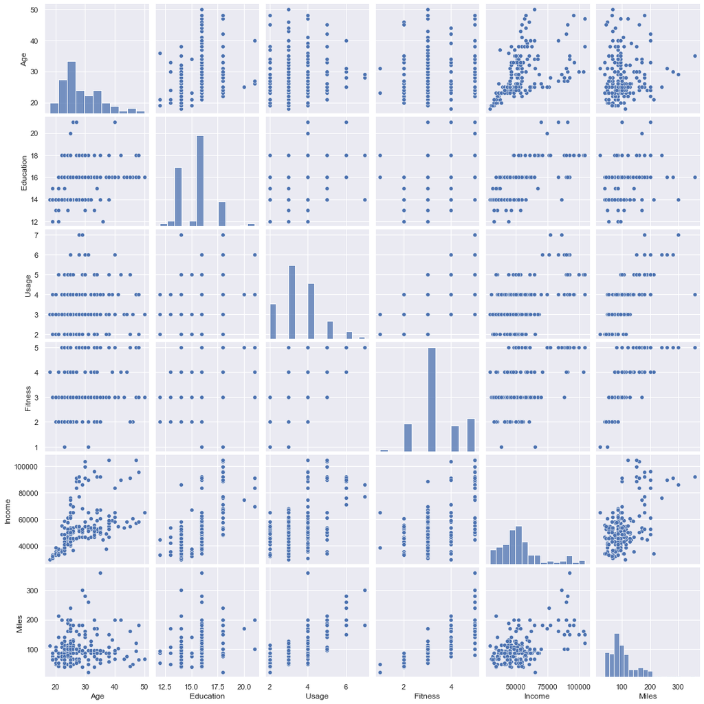

```python
#call pairplot function
sns.pairplot(data);
```

```python
# Get correlation matrix for numeric variables
data.corr()
```

|  | Age | Education | Usage | Fitness | Income | Miles |
| --- | --- | --- | --- | --- | --- | --- |
| Age | 1.000000 | 0.280496 | 0.015064 | 0.061105 | 0.513414 | 0.036618 |
| Education | 0.280496 | 1.000000 | 0.395155 | 0.410581 | 0.625827 | 0.307284 |
| Usage | 0.015064 | 0.395155 | 1.000000 | 0.668606 | 0.519537 | 0.759130 |
| Fitness | 0.061105 | 0.410581 | 0.668606 | 1.000000 | 0.535005 | 0.785702 |
| Income | 0.513414 | 0.625827 | 0.519537 | 0.535005 | 1.000000 | 0.543473 |
| Miles | 0.036618 | 0.307284 | 0.759130 | 0.785702 | 0.543473 | 1.000000 |

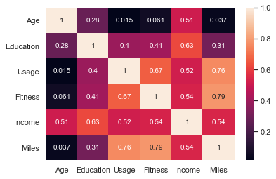

```python
# Display correlation matrix in a heatmap
sns.heatmap(data.corr(), annot=True);
```

From the previous charts we can infer that:

- Income has a positive correlation higher than 0.5 with Age, Education, Usage, Fitness and Miles.
- Usage has a positive correlation higher than 0.5 with Fitness, Income and Miles.
- Fitness has a positive correlation higher than 0.5 with Usage, Income and Miles.
- Miles has a positive correlation higher than 0.5 with Usage, Fitness and Income.

## 3.3 Analysis by Gender

In this section we are going to analyze the relationships between Gender and other variables

### 3.3.1 Usage and Fitness

The boxplot below shows the quartiles of Usage for the different Fitness categories for Male and Female

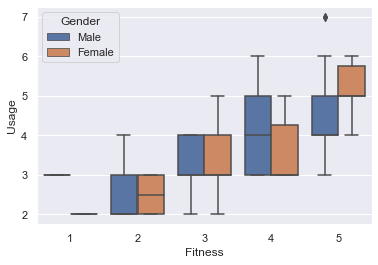

```python
# create boxplot chart
sns.boxplot(data['Fitness'], data['Usage'], hue=data['Gender']);
```

There is a positive correlation between Fitness and Usage for both Gender. Although, for Males with high Fitness Score (4 and 5) there is a higher variance in Usage compared with Females with same Fitness Score

### 3.3.2 Usage and Miles

The boxplot below shows the quartiles of Miles for different Usage levels for Male and Female

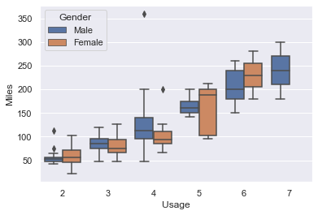

```python
# create boxplot chart
sns.boxplot(data['Usage'], data['Miles'], hue=data['Gender']);
```

There is a positive correlation between Miles and Usage for both Gender. The range of Miles run by Males is higher than Females for Usage of 4 times per week. However, the range of Miles run by Females is higher than Males for Usage of 5 times per week. There are no data for Females with Usage of 7 times per week.

For this analysis, it is interesting to analyze distribution of the ratio between Miles and Usage by Gender- using violinplot chart

```python
# new Series with the ratio between Miles and Usage
data['Miles_Usage'] = data['Miles']/data['Usage']
```

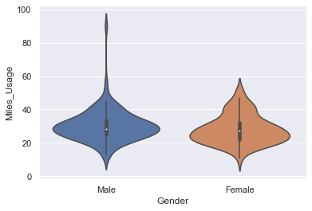

```python
# create violinplot chart
sns.violinplot(data['Gender'], data['Miles_Usage']);
```

This violinplot shows that Males run on average higher miles per usage than Females

## 3.4 Analysis by Product

In this section we are going to analyze the relationships between Product and other variables

### 3.4.1 Usage and Fitness

The boxplot below shows the quartiles of Usage for different Fitness levels for each Product

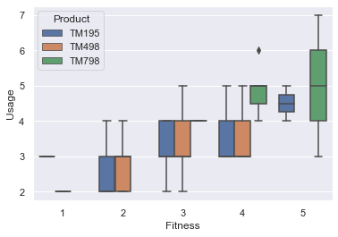

```python
# Create boxplot chart
sns.boxplot(data['Fitness'], data['Usage'], hue=data['Product']);
```

User with TM798 have higher Fitness Score (4 and 5), and the Usage is also higher than other 2 products

### 3.4.2 Usage and Miles

The swarmplot below shows the variability of Miles for different Usage levels for each Product

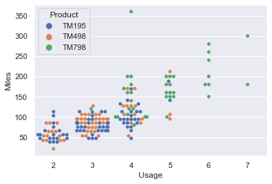

```python
# Create swarmplot chart
sns.swarmplot(data['Usage'], data['Miles'], hue=data['Product']);
```

It is clear that product TM798 has the highest Usage and Miles compared with other 2 products.

Now, we are going to analyze the distribution of the ration between Miles and Usage by Product

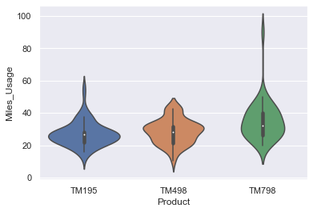

```python
# Create violinplot chart
sns.violinplot(data['Product'], data['Miles_Usage']);
```

The violinplot shows that users with TM798 run more miles per usage than users with other 2 products

## 3.5 Analysis by Marital Status

In this section we are going to analyze the relationships between Marital Status and other variables

### 3.5.1 Usage and Fitness

The boxplot below shows the Usage for different Fitness levels for Single and Partnered users

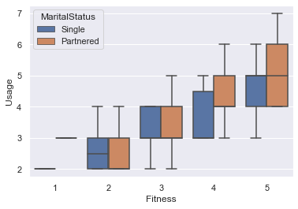

```python
# Create boxplot chart
sns.boxplot(data['Fitness'], data['Usage'], hue=data['MaritalStatus']);
```

Partnered users with high Fitness Score (4 and 5) have higher Usage than Single Users

### 3.5.2 Usage and Miles

The swarmplot below shows the Miles for different Usage levels for Single and Partnered users

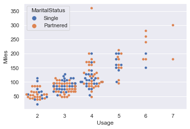

```python
# Create swarmplot chart
sns.swarmplot(data['Usage'], data['Miles'], hue=data['MaritalStatus']);
```

There is positive correlation between Usage and Miles for both Single and Partnered users. There are more Partnered users with high Usage (5, 6, and 7) than Single users

The violinplot below shows the distribution of Miles per Usage ration for Single and Partnered users

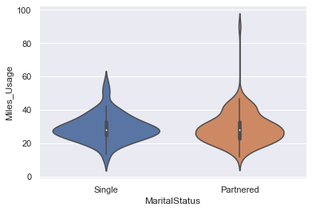

```python
# Create violinplot chart
sns.violinplot(data['MaritalStatus'], data['Miles_Usage']);
```

## 3.6 Analysis by Gender and Product

In this section we analyze the relation between Gender and Product and other variables

### 3.6.1 Usage and Miles

The swarm charts below shows the variability of Miles for different Usage levels for both Gender and each Product

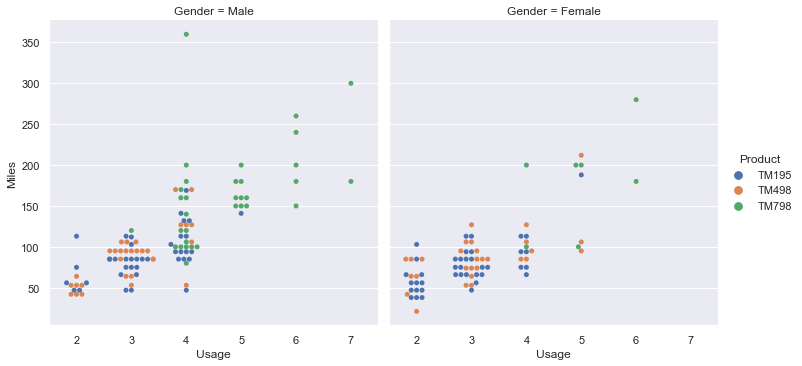

```python
# Create swarm chart using catplot function
sns.catplot(x='Usage', y='Miles', hue='Product', col='Gender', data=data, kind='swarm');
```

This charts confirms the analysis perform in 3.3.2 section. Although, there are a less Female Users with TM798 product than Male Users, TM798 product has the highest Usage and Miles for both Genders

### 3.6.2 Fitness and Miles

The swarm chart below shows the Miles for different Fitness levels for both Gender and each Product

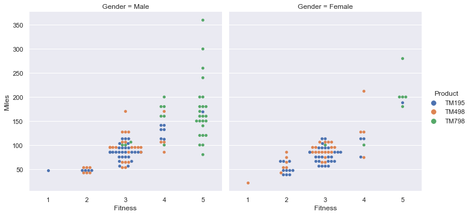

```python
# Create swarm chart using catplot function
sns.catplot(x='Fitness', y='Miles', hue='Product', col='Gender', data=data, kind='swarm');
```

Both Males and Females users with TM798 product have higher Fitness level and Miles

### 3.6.3 Usage and Education

In this section we are going to analyze relationship between Usage and Education with Gender and Product

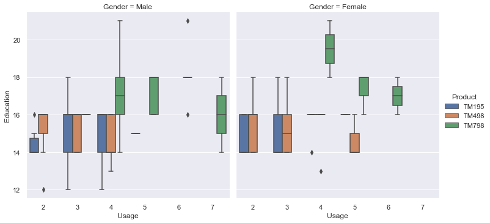

```python
# Create box chart using catplot function
sns.catplot(x='Usage', y='Education', col='Gender', hue='Product', data=data, kind='box');
```

Male and Female users with TM798 product have higher Education and Usage

### 3.6.4 Fitness and Income

In this section we are going to analyze the relationship between Fitness and Income with Gender and Product

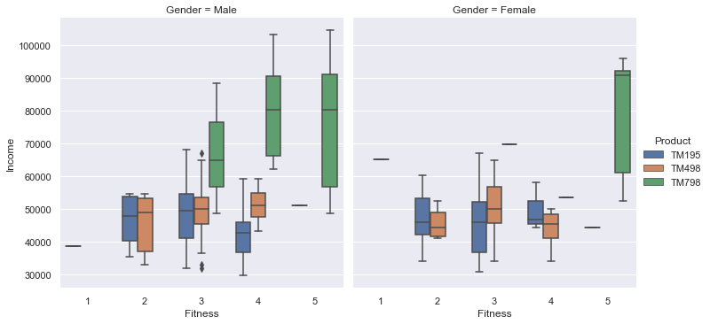

```python
# Create box chart using catplot function
sns.catplot(x='Fitness', y='Income', col='Gender', hue='Product', data=data, kind='box');
```

Males and Female users with TM798 product have higher Income and Fitness level

### 3.6.5 Fitness and Age

In this section we are going to analyze the relationship between Fitness and Age with Gender and Product

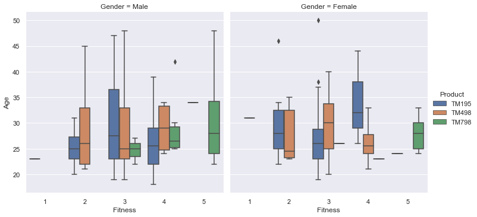

```python
# Create box chart using catplot function
sns.catplot(x='Fitness', y='Age', col='Gender', hue='Product', data=data, kind='box');
```

## 3.7 Analysis by Product and Marital Status

In this section we are going to analyze the relationship between Product and Marital Status with other variables

### 3.7.1 Fitness and Miles

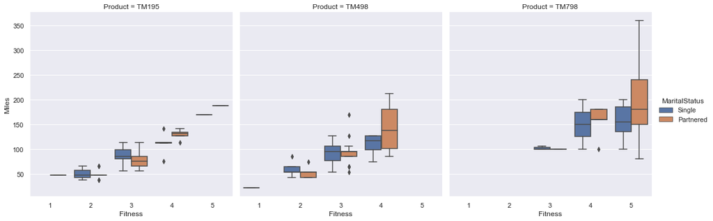

```python
# Create box chart using catplot function
sns.catplot(x='Fitness', y='Miles', col='Product', hue='MaritalStatus', data=data, kind='box');
```

### 3.7.2 Fitness and Income

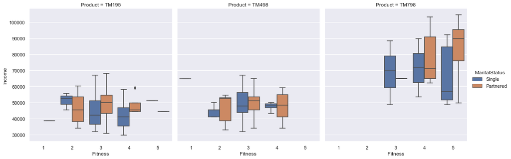

```python
# Create box chart using catplot function
sns.catplot(x='Fitness', y='Income', col='Product', hue='MaritalStatus', data=data, kind='box');
```

Both Single and Partnered users with TM798 product have higher Income and Fitness level

### 3.7.3 Education and Usage

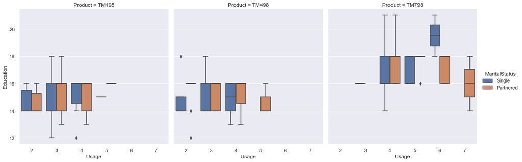

```python
# Create box chart using catplot function
sns.catplot(x='Usage', y='Education', col='Product', hue='MaritalStatus', data=data, kind='box');
```

Both Single and Partnered users with TM798 product have higher Education and Usage

# 4 Conclusions and recommendations

## 4.1 Customer profile

From the previous univariate and multivariate analysis we can conclude that each product have an specific characteristics of customers. Product TM798 in the top tier. Product TM498 in the medium tier. Product TM195 in the bottom tier.

### 4.1.1 Product TM798

Although, TM798 is the less popular product (22.2%), there is a clear profile of the users with the product:

- Mostly Male (33 Male vs 7 Female)
- Mostly Partnered (23 Partnered vs 17 Single)
- Higher Income (Avg 75441.57 - Male 75825.03, Female 73633.85). Partnered customers have higher average income than single customers (82047.17 Partnered vs 66504.58 Single)
- Higher Education (Avg 17.32 years, Male 17.2, Female 17.8)
- Higher Fitness level (Avg 4.62, Male 4.63, Female 4.57)
- Higher Usage (Avg 4.77 times - Male 4.72, Female 5)
- Higher Miles (Avg 166.9 - Male 164, Female 180 - Partnered 183, Single 145)

### 4.1.2 Product TM498

TM498 is in the middle in terms of number of users (33.4%). The characteristics of the customers are:

- There is no important difference between number of Males and Females users (31 Male vs 29 Female). There is also no important difference in other variables between Males and Females.
- Mostly Partnered (36 Partnered vs 24 Single)
- Medium/Low Income (Avg 48973.65)
- Medium Education (Avg 15.11 years)
- Medium/Low Fitness level (Avg 2.9)
- Medium Usage (Avg 3 times)
- Medium Miles (Avg 87.9, Partnered 90, Single 84.7)
- Partnered users are in average older than single customers (30.2 Partnered vs 26.9 Single)

### 4.1.3 Product TM195

TM195 is the most popular product (44.4%). The characteristics of the customers are:

- Same number of Males and Females (40 customers each group). There is no important difference in other variables between Male and Female
- Mostly Partnered (48 Partnered vs 32 Single)
- Medium/Low Income (Avg 46418)
- Medium Education (Avg 15.03 years)
- Medium/Low Fitness level (Avg 2.9)
- Medium Usage (Avg 3 times)
- Low Miles (Avg 82.7, Partnered 77, Single 91, Female 76, Male 89)

## 4.2 Recommendations

The company can target each product for different type of customers.

- Product TM798 should be targeted at customers with higher Income and Education level. This costumers are going to present higher Fitness level and Usage with this product.
- Product TM498 should be targeted at Partnered customers with medium Income. This costumers are going to run more miles in average than Single customers
- Product TM195 should be targeted at Male and Single customers with medium/low Income. This costumers are going to run more miles in average than Partnered and Female customers.